# HW 1

Josh Winnes

2025-01-23

# Section 1.2.5

## Exercise 1

```r
glimpse(penguins)
```

```
## Rows: 344
## Columns: 8
## $ species           <fct> Adelie, Adelie, Adelie, Adelie, Adelie, Adelie, Adel…
## $ island            <fct> Torgersen, Torgersen, Torgersen, Torgersen, Torgerse…
## $ bill_length_mm    <dbl> 39.1, 39.5, 40.3, NA, 36.7, 39.3, 38.9, 39.2, 34.1, …
## $ bill_depth_mm     <dbl> 18.7, 17.4, 18.0, NA, 19.3, 20.6, 17.8, 19.6, 18.1, …
## $ flipper_length_mm <int> 181, 186, 195, NA, 193, 190, 181, 195, 193, 190, 186…
## $ body_mass_g       <int> 3750, 3800, 3250, NA, 3450, 3650, 3625, 4675, 3475, …
## $ sex               <fct> male, female, female, NA, female, male, female, male…
## $ year              <int> 2007, 2007, 2007, 2007, 2007, 2007, 2007, 2007, 2007…
```

There are 344 rows and 8 columns in the penguins dataframe.

## Exercise 2

```r
?penguins
```

The `bill_depth_mm` column is “a number denoting bill depth (millimeters)”.

## Exercise 3

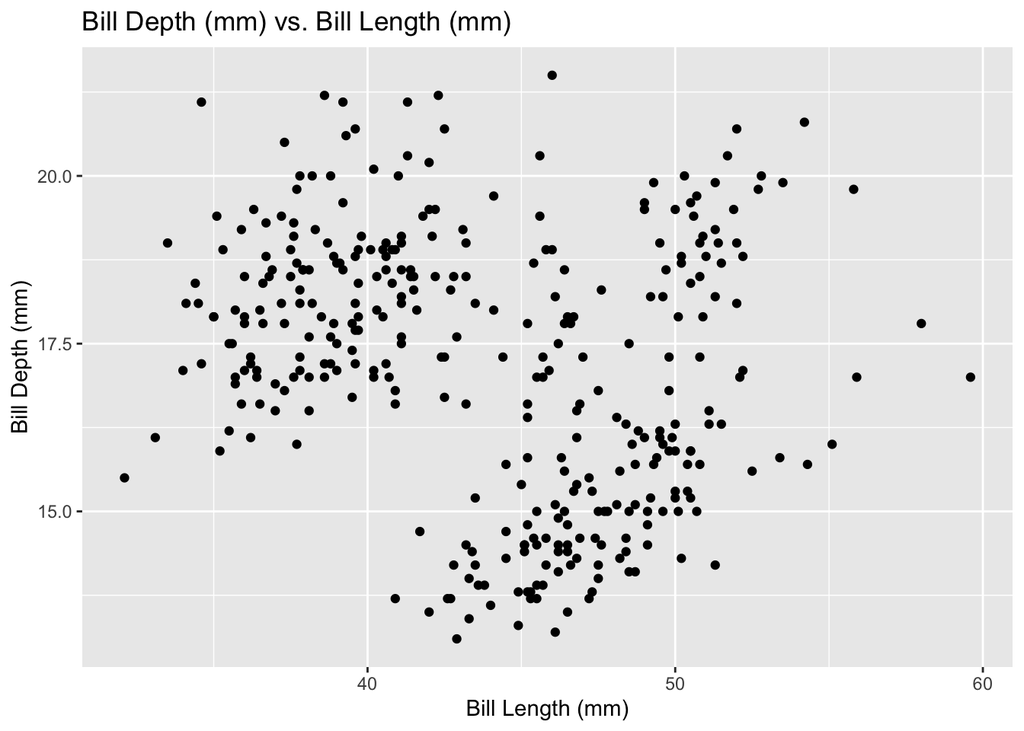

```r
plot3 <- ggplot(penguins, aes(x = bill_length_mm, y=bill_depth_mm)) +
  geom_point() +
  labs(
    title = "Bill Depth (mm) vs. Bill Length (mm)",
    x = "Bill Length (mm)",
    y = "Bill Depth (mm)"
  )

plot3
```

## Exercise 4

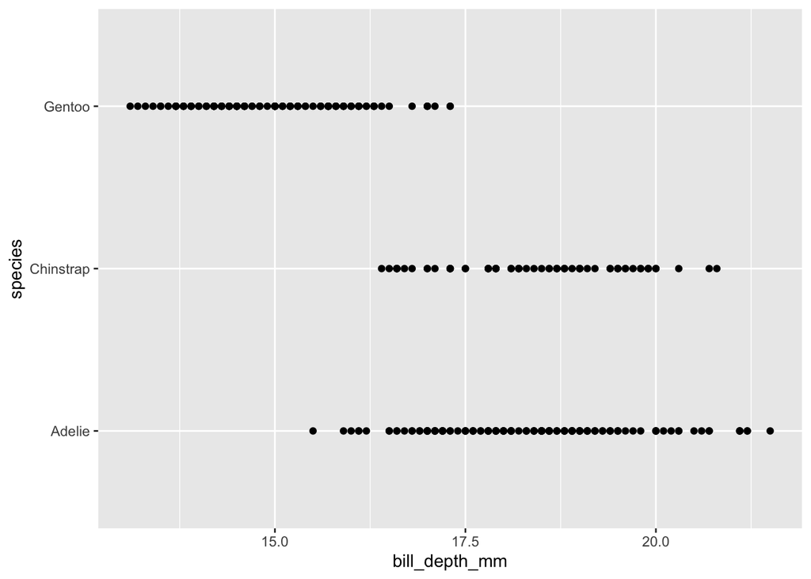

```r
plot4 <- ggplot(penguins, aes(x = bill_depth_mm, y=species)) +
  geom_point()

plot4
```

A better choice of geom would be `geom_boxplot()`.

## Exercise 5

```
ggplot(data = penguins) +
  geom_point()
```

This gives an error because there is no aesthetic mapping. You would fix it by adding an aesthetic layer either globally in the `ggplot()` declaration or locally in the `geom_point()` layer.

## Exercise 6

According to the `?geom_point` page, “If `FALSE`, the default, missing values are removed with a warning. If `TRUE`, missing values are silently removed.” For example:

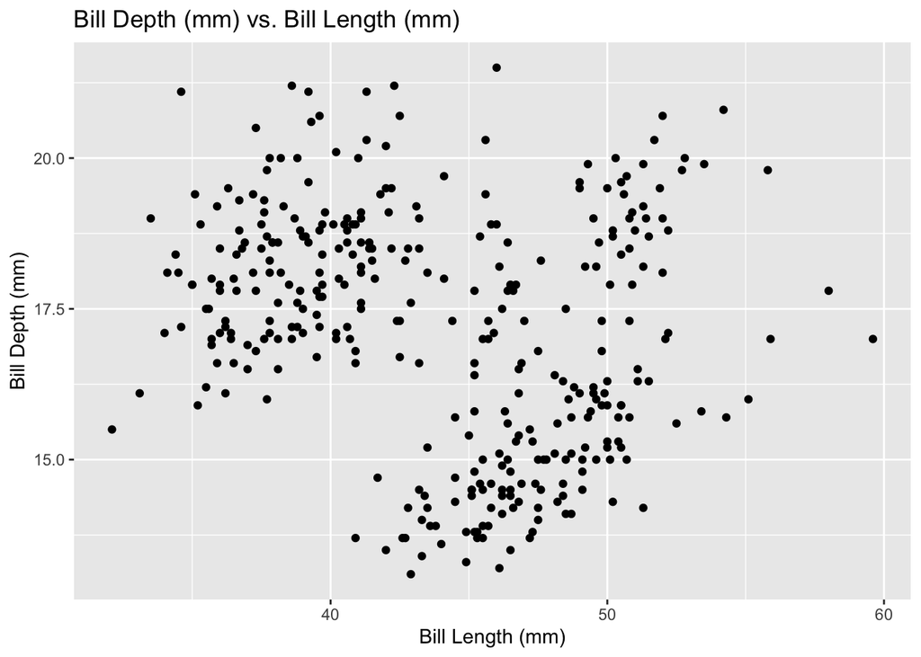

```r
plot6 <- ggplot(penguins, aes(x = bill_length_mm, y=bill_depth_mm)) +
  geom_point(na.rm = TRUE) +
  labs(
    title = "Bill Depth (mm) vs. Bill Length (mm)",
    x = "Bill Length (mm)",
    y = "Bill Depth (mm)"
  )

plot6
```

## Exercise 7

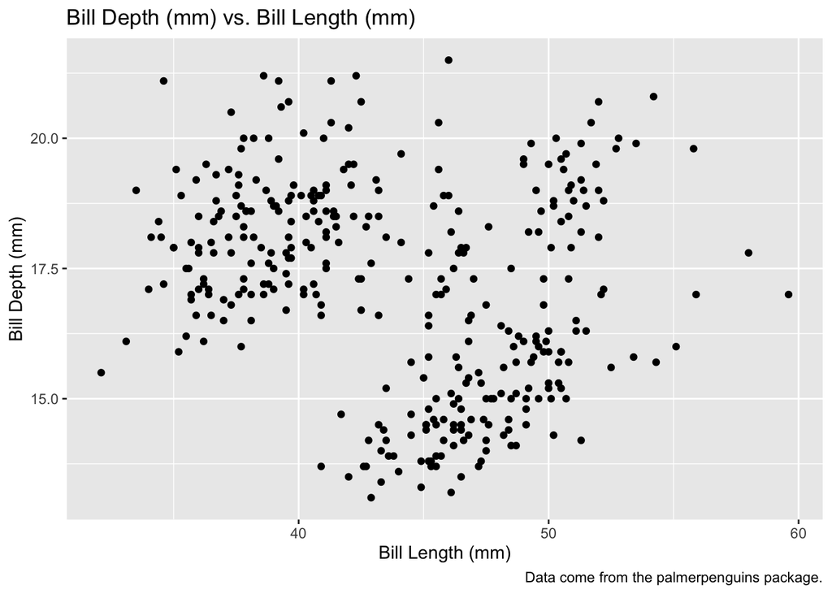

```r
plot7 <- ggplot(penguins, aes(x = bill_length_mm, y=bill_depth_mm)) +
  geom_point(na.rm = TRUE) +
  labs(
    title = "Bill Depth (mm) vs. Bill Length (mm)",
    x = "Bill Length (mm)",
    y = "Bill Depth (mm)",
    caption = "Data come from the palmerpenguins package."
  )

plot7
```

## Exercise 8

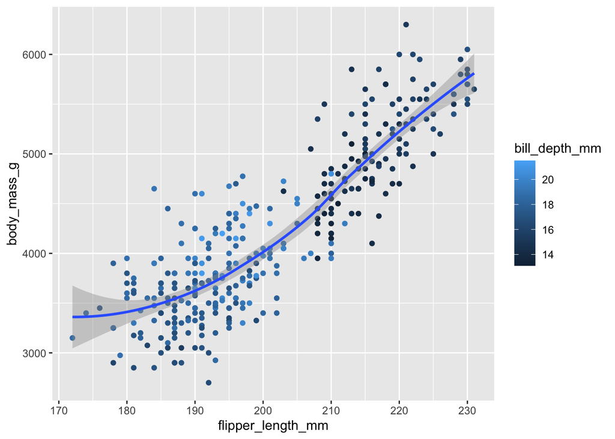

```r
plot8 <- ggplot(penguins, aes(x=flipper_length_mm, y=body_mass_g))+
  geom_point(aes(color=bill_depth_mm))+
  geom_smooth()

plot8
```

# Section 1.4.3

## Exercise 1

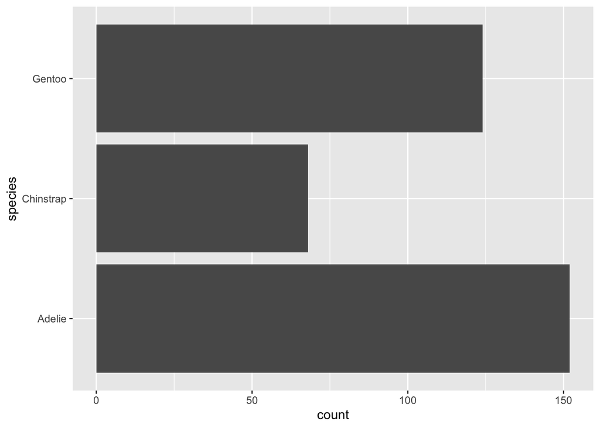

```r
plot1 <- ggplot(penguins) +
  geom_bar(aes(y=species))

plot1
```

## Exercise 2

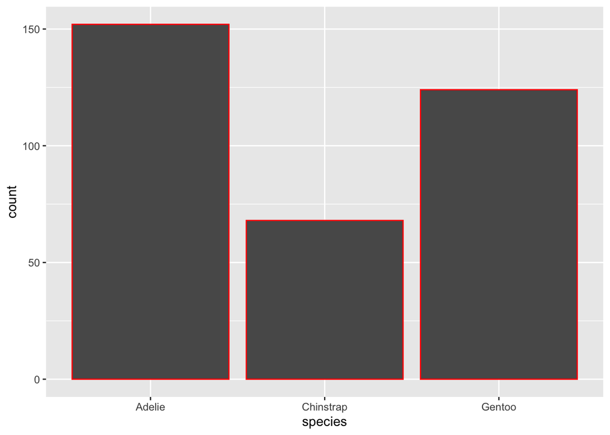

```r
ggplot(penguins, aes(x = species)) +
  geom_bar(color = "red")
```

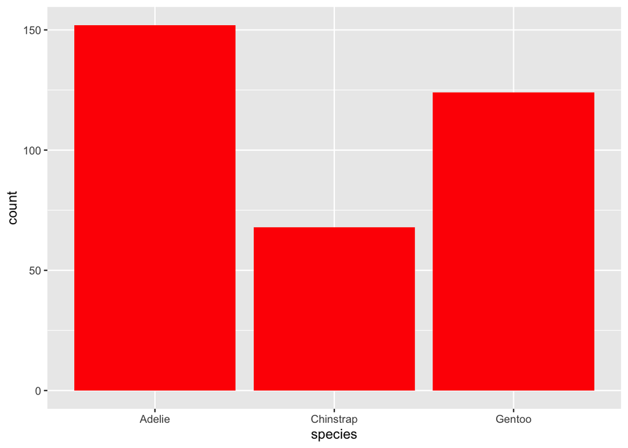

```r
ggplot(penguins, aes(x = species)) +
  geom_bar(fill = "red")
```

They are the same chart except that the first one has a red border around the grey boxes while the second one has the boxes filled in with the color red. `fill` is far more useful for changing the color of the boxes.

# Section 1.5.5

## Exercise 1

```r
?mpg
mpg
```

```
## # A tibble: 234 × 11
##    manufacturer model      displ  year   cyl trans drv     cty   hwy fl    class
##    <chr>        <chr>      <dbl> <int> <int> <chr> <chr> <int> <int> <chr> <chr>
##  1 audi         a4           1.8  1999     4 auto… f        18    29 p     comp…
##  2 audi         a4           1.8  1999     4 manu… f        21    29 p     comp…
##  3 audi         a4           2    2008     4 manu… f        20    31 p     comp…
##  4 audi         a4           2    2008     4 auto… f        21    30 p     comp…
##  5 audi         a4           2.8  1999     6 auto… f        16    26 p     comp…
##  6 audi         a4           2.8  1999     6 manu… f        18    26 p     comp…
##  7 audi         a4           3.1  2008     6 auto… f        18    27 p     comp…
##  8 audi         a4 quattro   1.8  1999     4 manu… 4        18    26 p     comp…
##  9 audi         a4 quattro   1.8  1999     4 auto… 4        16    25 p     comp…
## 10 audi         a4 quattro   2    2008     4 manu… 4        20    28 p     comp…
## # ℹ 224 more rows
```

## Exercise 2

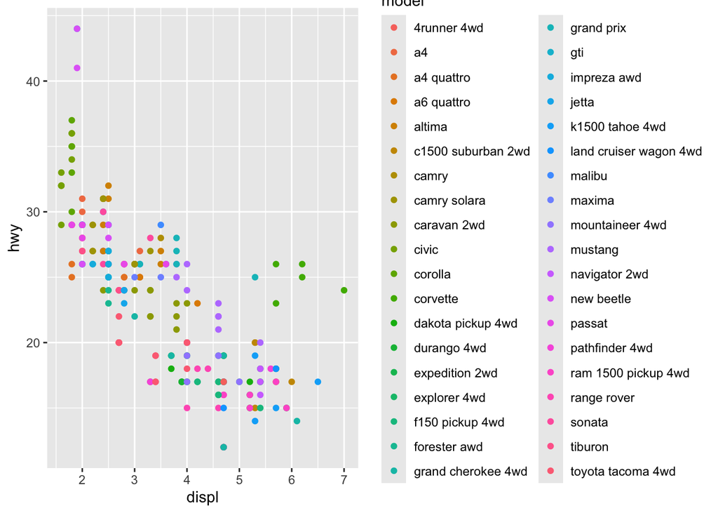

```r
ggplot(mpg, aes(x=displ, y=hwy))+
  geom_point(aes(color=model))
```

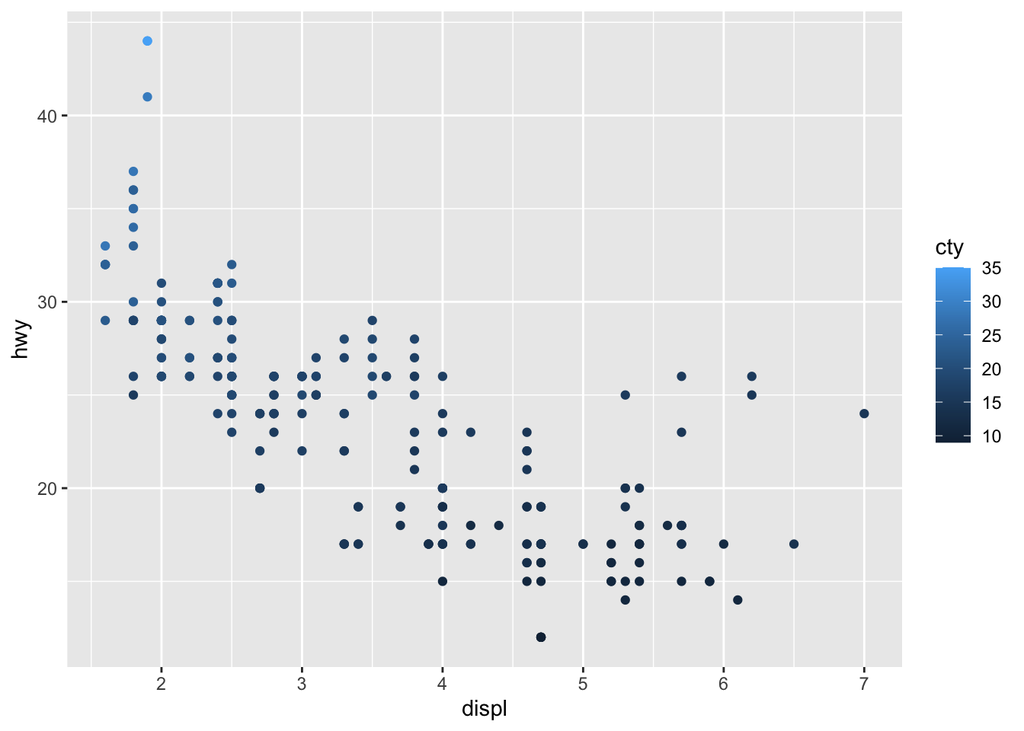

```r
ggplot(mpg, aes(x=displ, y=hwy))+
  geom_point(aes(color=cty))
```

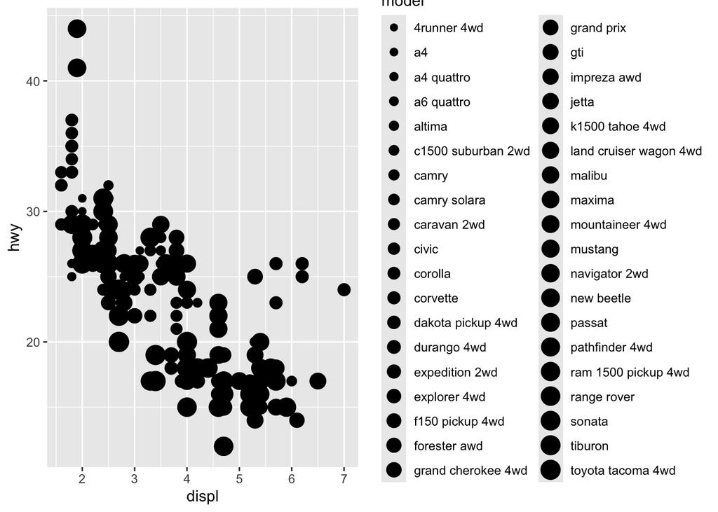

```r
ggplot(mpg, aes(x=displ, y=hwy))+
  geom_point(aes(size=model))
```

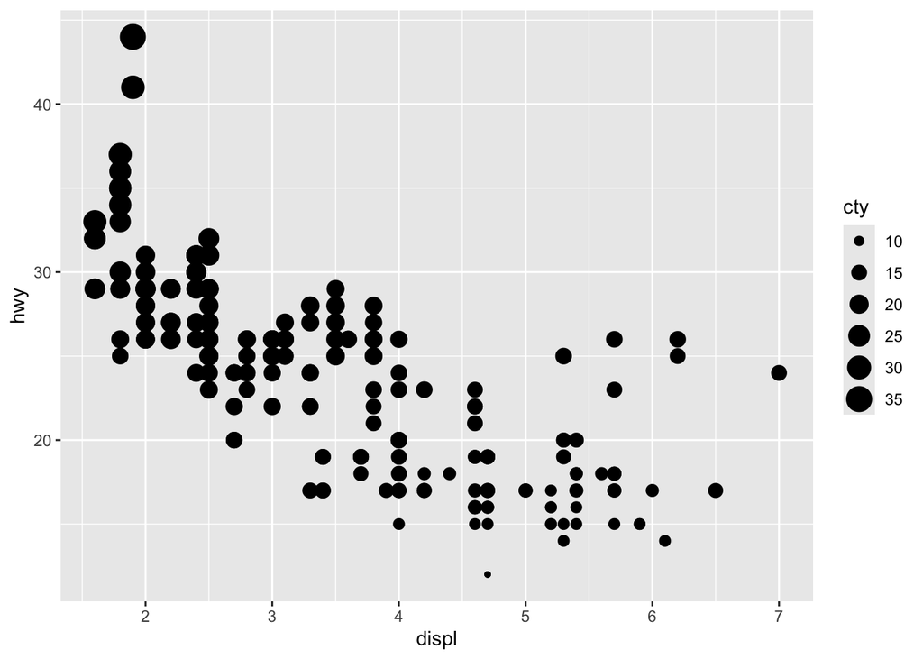

```r
ggplot(mpg, aes(x=displ, y=hwy))+
  geom_point(aes(size=cty))
```

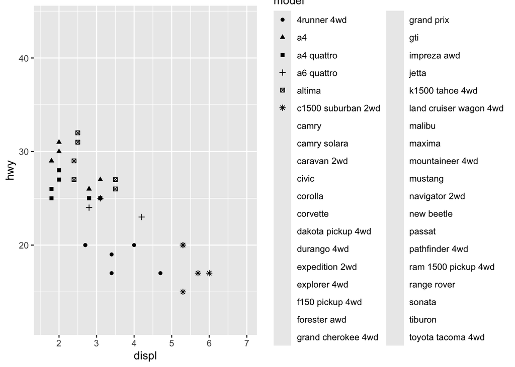

```r
ggplot(mpg, aes(x=displ, y=hwy))+
  geom_point(aes(shape=model))
```

```r
# doesn't run because shape has to be assigned to a categorical variable
# ggplot(mpg, aes(x=displ, y=hwy))+
  # geom_point(aes(shape=cty))
```

The plots above show how `color`, `shape`, and `size` affect the scatterplot when they are mapped to categorical vs. continuous variables. In this case, there are so many models that the colors are hard to distinguish and there actually aren’t enough shapes. Also, shapes cannot be mapped to a continuous variable because shapes are not continuous.

## Exercise 3

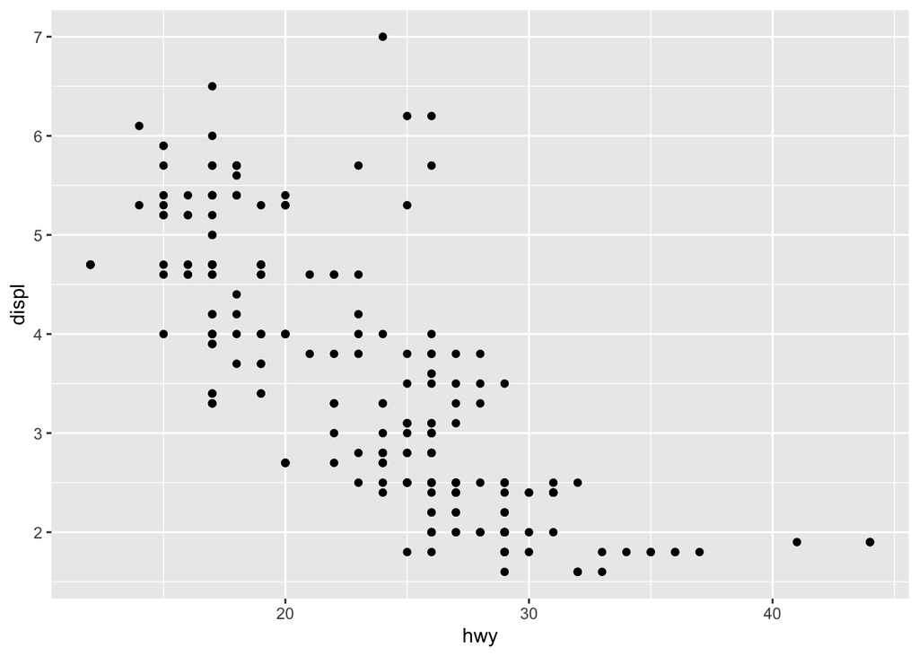

```r
ggplot(mpg)+
  geom_point(aes(x=hwy, y=displ, linewidth=cty))
```

It doesn’t look like anything happens when you map a third variable to `linewidth` which makes sense because this is a scatterplot so there aren’t actually any lines, just points.

# Section 11.2.1

## Exercise 1

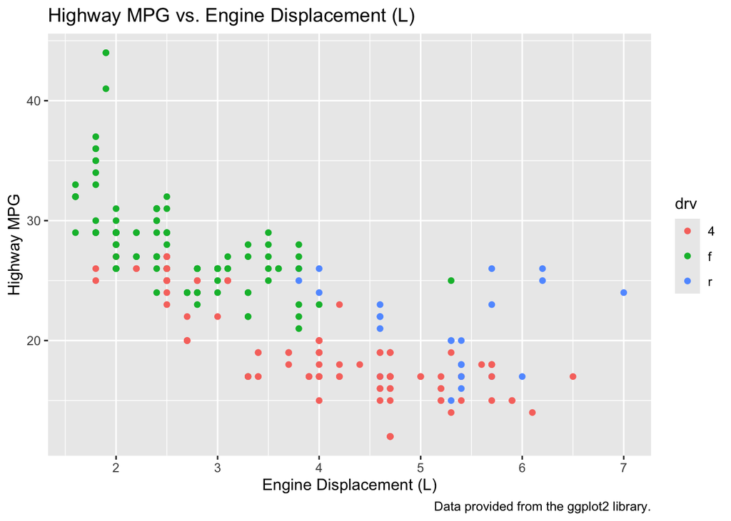

```r
ggplot(mpg, aes(x=displ, y=hwy))+
  geom_point(aes(color=drv))+
  labs(
    title = "Highway MPG vs. Engine Displacement (L)",
    caption = "Data provided from the ggplot2 library.",
    x = "Engine Displacement (L)",
    y = "Highway MPG",
    drv = "Drive Train"
  )
```

## Exercise 2

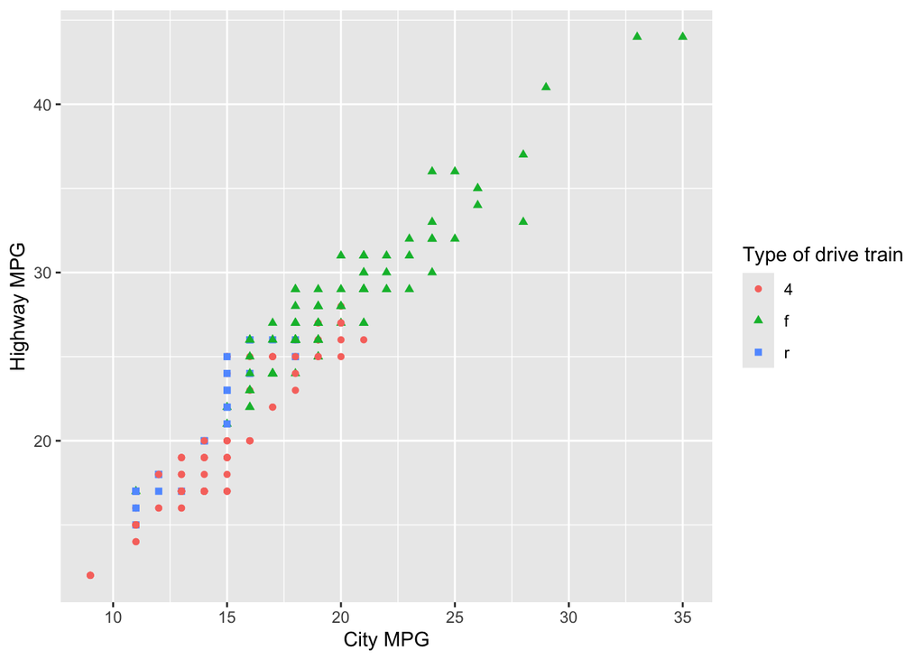

```r
ggplot(mpg, aes(x=cty, y=hwy))+
  geom_point(aes(color=drv, shape=drv))+
  labs(
    x = "City MPG",
    y = "Highway MPG",
    color = "Type of drive train",
    shape = "Type of drive train"
  )
```

# Section 11.3.1

## Exercise 4

Just like other layers, the `aes()` argument in `geom_label()` can be filled with parameters like `color`, `fill`, `size`, etc. which control the appearance of the background box.

# Section 11.4.6

## Exercise 3

### Part A

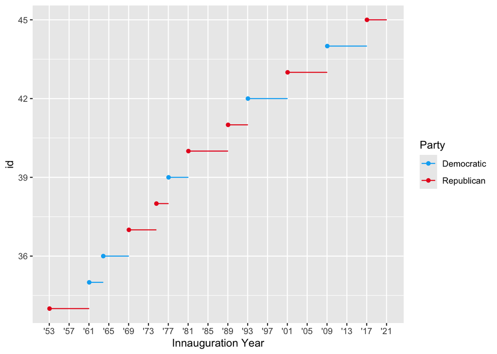

```r
presidential |>
  mutate(id = 33 + row_number()) |>
  ggplot(aes(x = start, y = id, color = party)) +
  geom_point() +
  geom_segment(aes(xend = end, yend = id)) +
  scale_color_manual(name = "Party", values = c(Republican = "#E81B23", Democratic = "#00AEF3"))+
  scale_x_date(name = "Innauguration Year", date_breaks="4 year", minor_breaks=NULL, date_labels = "'%y")
```

To be totally honest, even after reading the chapter, I’m not really sure what the question means when it says to “combine the variants,” so I just cleaned up the x axis and color scale.

### Part B

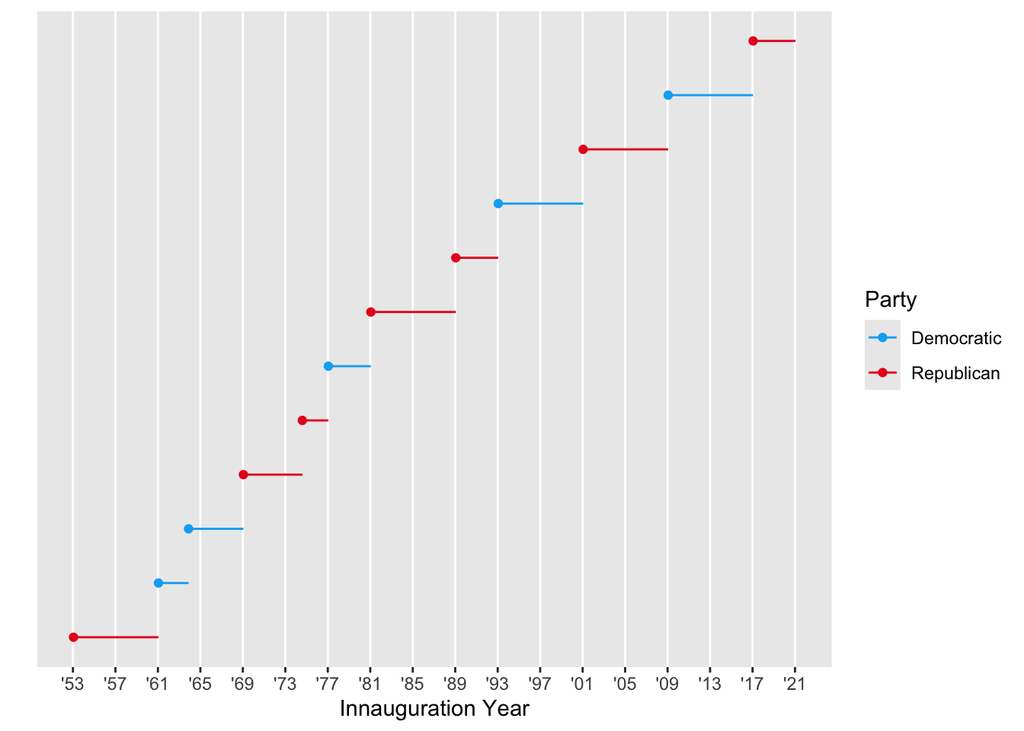

```r
presidential |>
  mutate(id = 33 + row_number()) |>
  ggplot(aes(x = start, y = id, color = party)) +
  geom_point() +
  geom_segment(aes(xend = end, yend = id)) +
  scale_color_manual(name = "Party", values = c(Republican = "#E81B23", Democratic = "#00AEF3"))+
  scale_x_date(name = "Innauguration Year", date_breaks="4 year", minor_breaks=NULL, date_labels = "'%y") +
  scale_y_continuous(name = "", labels = NULL, breaks = 0)
```

### Part C

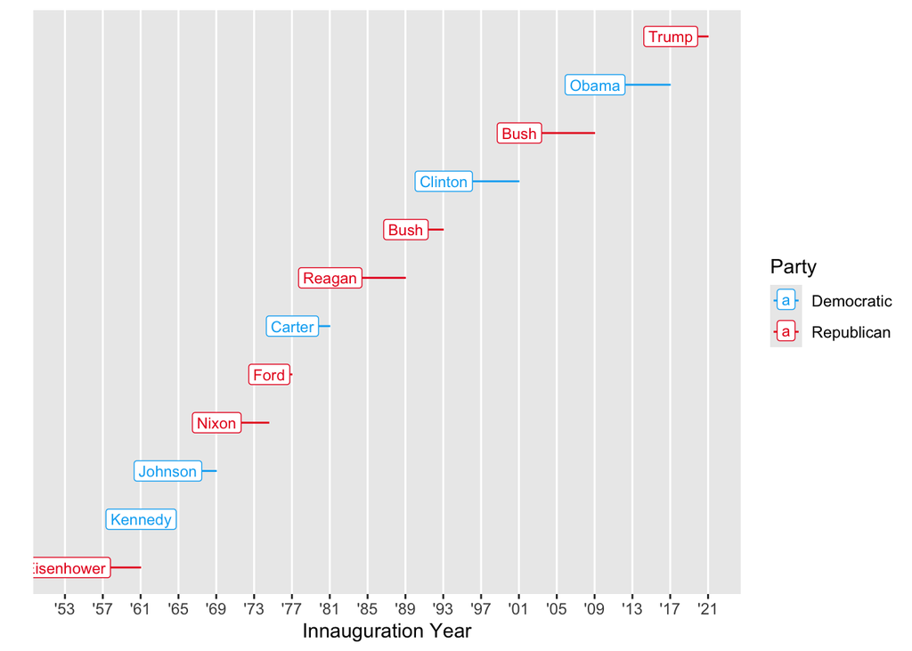

```r
presidential |>
  mutate(id = 33 + row_number()) |>
  ggplot(aes(x = start, y = id, color = party)) +
  geom_point() +
  geom_segment(aes(xend = end, yend = id)) +
  geom_label(aes(label=name), size=3) +
  scale_color_manual(name = "Party", values = c(Republican = "#E81B23", Democratic = "#00AEF3"))+
  scale_x_date(name = "Innauguration Year", date_breaks="4 year", minor_breaks=NULL, date_labels = "'%y") +
  scale_y_continuous(name = "", labels = NULL, breaks = 0)
```

### Part D

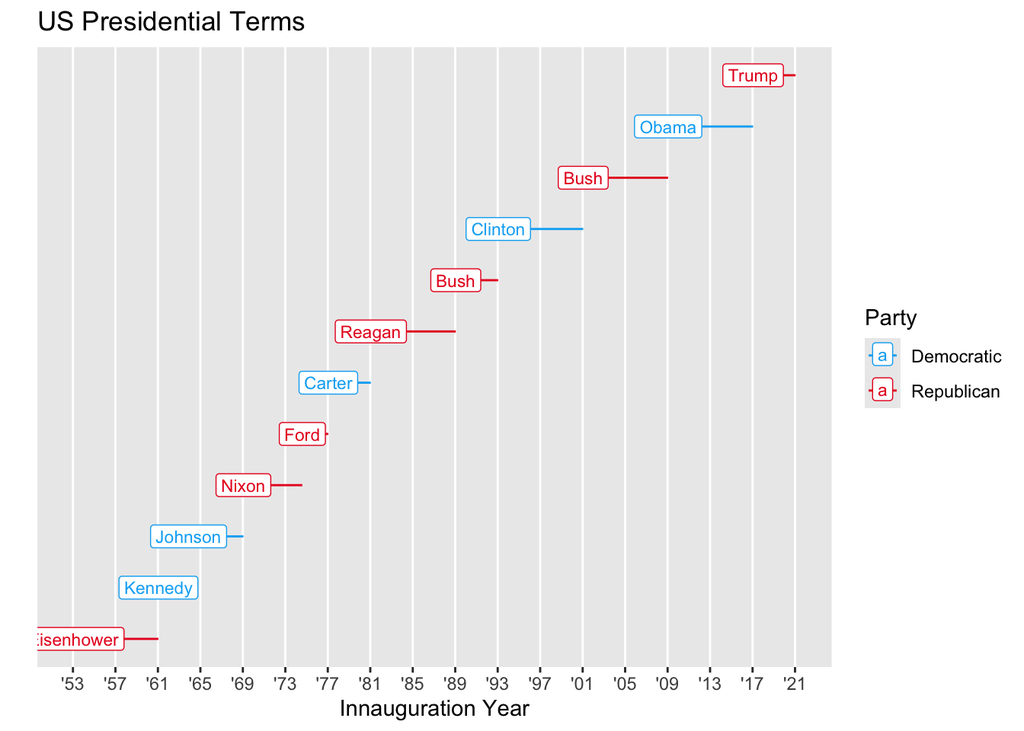

```r
presidential |>
  mutate(id = 33 + row_number()) |>
  ggplot(aes(x = start, y = id, color = party)) +
  geom_point() +
  geom_segment(aes(xend = end, yend = id)) +
  geom_label(aes(label=name), size=3) +
  scale_color_manual(name = "Party", values = c(Republican = "#E81B23", Democratic = "#00AEF3"))+
  scale_x_date(name = "Innauguration Year", date_breaks="4 year", minor_breaks=NULL, date_labels = "'%y") +
  scale_y_continuous(name = "", labels = NULL, breaks = 0) +
  labs(
    title = "US Presidential Terms",
  )
```

### Part E

Already done in Part A.